# FactorModel

# Plot actual vs. fitted over time

# Use chart.TimeSeries() function from PerformanceAnalytics package

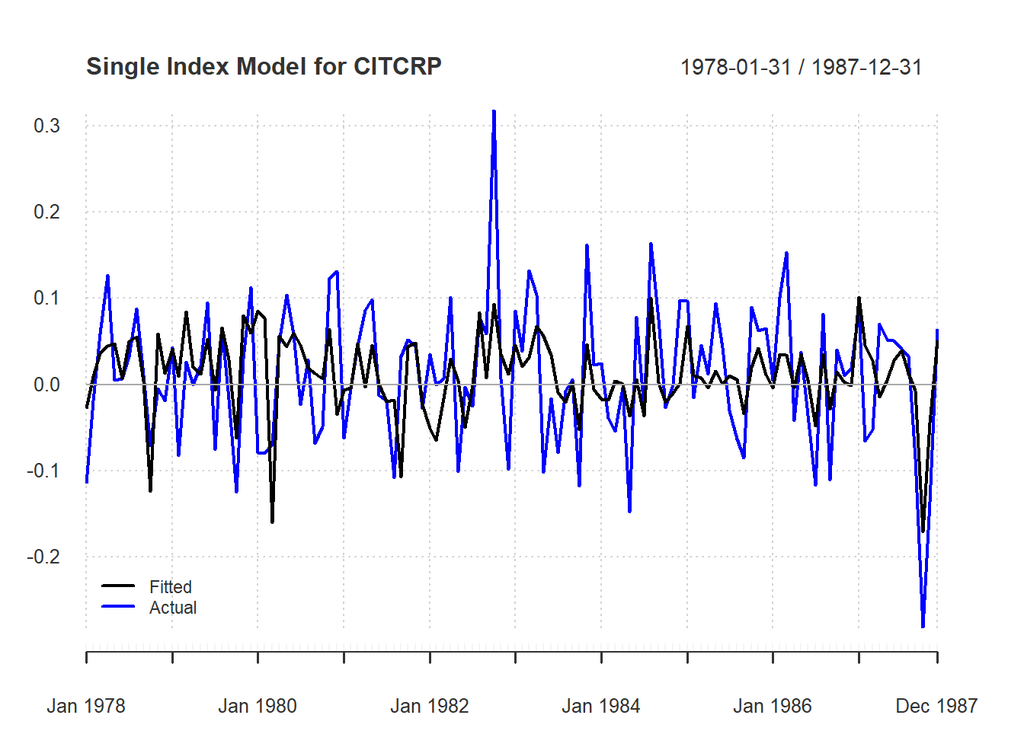

```r
dataToPlot = cbind(fitted(reg.list$CITCRP), retdata$CITCRP)
colnames(dataToPlot) = c("Fitted","Actual")
dataToPlot.xts<-as.xts(dataToPlot, order.by = retdata$date)
chart.TimeSeries(dataToPlot.xts, main="Single Index Model for CITCRP",
                 colorset=c("black","blue"), legend.loc="bottomleft")
```

# Scatterplot of the single index model regression

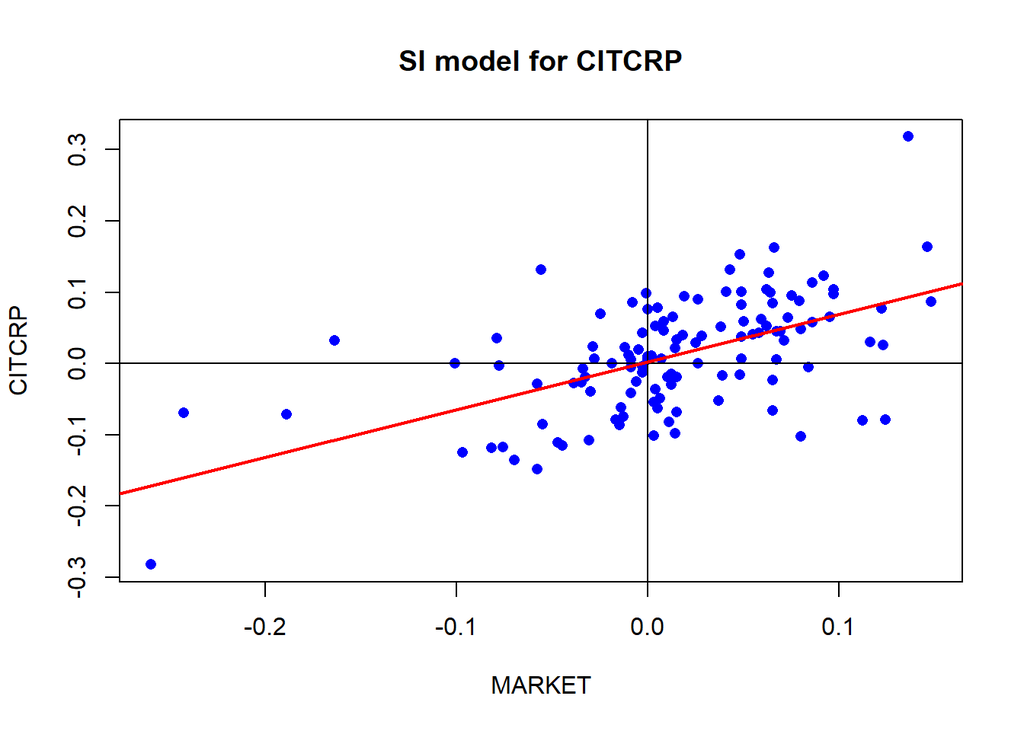

```r
plot(retdata$MARKET, retdata$CITCRP, main="SI model for CITCRP",
     type="p", pch=16, col="blue",
     xlab="MARKET", ylab="CITCRP")
abline(h=0, v=0)
abline(reg.list$CITCRP, lwd=2, col="red")
```

#================================================================================== # Extract beta values, residual sd’s and R2’s from list of regression objects #================================================================================== # Brute force loop

```r
reg.vals = matrix(0, length(asset.names), 3)
rownames(reg.vals) = asset.names
colnames(reg.vals) = c("beta", "residual.sd", "r.square")
for (i in names(reg.list)) {
  tmp.fit = reg.list[[i]]
  tmp.summary = summary(tmp.fit)
  reg.vals[i, "beta"] = coef(tmp.fit)[2]
  reg.vals[i, "residual.sd"] = tmp.summary$sigma
  reg.vals[i, "r.square"] = tmp.summary$r.squared
}
reg.vals
```

```
##           beta residual.sd r.square
## CITCRP 0.66778     0.06716  0.31777
## CONED  0.09102     0.05010  0.01532
## CONTIL 0.73836     0.14260  0.11216
## DATGEN 1.02816     0.10688  0.30363
## DEC    0.84305     0.08102  0.33783
## DELTA  0.48946     0.09029  0.12163
## GENMIL 0.26776     0.06268  0.07919
## GERBER 0.62481     0.07697  0.23694
## IBM    0.45302     0.05046  0.27523
## MOBIL  0.71352     0.06407  0.36882
## PANAM  0.73014     0.12251  0.14337
## PSNH   0.21263     0.10896  0.01763
## TANDY  1.05549     0.10565  0.31986
## TEXACO 0.61328     0.06808  0.27661
## WEYER  0.81687     0.06445  0.43083
```

# Alternatively use R apply function for list objects - lapply or sapply

```r
extractRegVals = function(x) {
  # x is an lm object
  beta.val = coef(x)[2]
  residual.sd.val = summary(x)$sigma
  r2.val = summary(x)$r.squared
  ret.vals = c(beta.val, residual.sd.val, r2.val)
  names(ret.vals) = c("beta", "residual.sd", "r.square")
  return(ret.vals)
}
reg.vals = sapply(reg.list, FUN=extractRegVals)
t(reg.vals)
```

```
##           beta residual.sd r.square
## CITCRP 0.66778     0.06716  0.31777
## CONED  0.09102     0.05010  0.01532
## CONTIL 0.73836     0.14260  0.11216
## DATGEN 1.02816     0.10688  0.30363
## DEC    0.84305     0.08102  0.33783
## DELTA  0.48946     0.09029  0.12163
## GENMIL 0.26776     0.06268  0.07919
## GERBER 0.62481     0.07697  0.23694
## IBM    0.45302     0.05046  0.27523
## MOBIL  0.71352     0.06407  0.36882
## PANAM  0.73014     0.12251  0.14337
## PSNH   0.21263     0.10896  0.01763
## TANDY  1.05549     0.10565  0.31986
## TEXACO 0.61328     0.06808  0.27661
## WEYER  0.81687     0.06445  0.43083
```

# ========================================================================

# Fundamental Factor Models

# ========================================================================

# Continue to use Berndt data for illustration of industry factor model

# —————————————-

# Industry factor model

# —————————————-

# Create loading matrix B for industry factor model

```r
n.stocks = ncol(returns.mat)
tech.dum = oil.dum = other.dum = matrix(0,n.stocks,1)
rownames(tech.dum) = rownames(oil.dum) = rownames(other.dum) = asset.names
tech.dum[c(4,5,9,13),] = 1
oil.dum[c(3,6,10,11,14),] = 1
other.dum = 1 - tech.dum - oil.dum
B.mat = cbind(tech.dum,oil.dum,other.dum)
colnames(B.mat) = c("TECH","OIL","OTHER")
```

# Show the factor sensitivity matrix

```r
B.mat
```

```
##        TECH OIL OTHER
## CITCRP    0   0     1
## CONED     0   0     1
## CONTIL    0   1     0
## DATGEN    1   0     0
## DEC       1   0     0
## DELTA     0   1     0
## GENMIL    0   0     1
## GERBER    0   0     1
## IBM       1   0     0
## MOBIL     0   1     0
## PANAM     0   1     0
## PSNH      0   0     1
## TANDY     1   0     0
## TEXACO    0   1     0
## WEYER     0   0     1
```

```r
colSums(B.mat)
```

```
##  TECH   OIL OTHER
##     4     5     6
```

# Returns.mat is T x N matrix, and fundamental factor model treats R as N x T.

```r
returns.mat = t(returns.mat)
```

# ————————————————————–

# Step 1: Estimate OLS F.hat —-

# ————————————————————–

# Multivariate OLS regression to estimate K x T matrix of factor returns (K=3)

```r
F.hat = solve(crossprod(B.mat))%*%t(B.mat)%*%returns.mat
```

# Rows of F.hat are time series of estimated industry factors (K X T)

```r
F.hat.df<-data.frame(t(F.hat))
F.hat.df$date<-as.Date(retdata$date)
```

```r
library(reshape2)
library(tidyverse)
```

# Plot muliple time series using ggplot

# Original codings

[figure not shown]

```r
             A<-melt(F.hat.df,"date")
             ggplot(A,aes(x=date, y=value))
```

# It’s same as code below # Percentage symbol = pipe functions, don’t have to type the data again like above

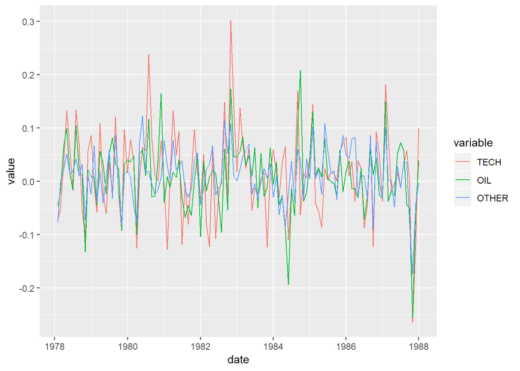

```r
p<-F.hat.df %>% melt("date") %>%
  ggplot(aes(x = date, y = value, group=variable,color=variable)) +
    geom_line() +
    scale_x_date()
p
```

# Compute residual variance from OLS regression —- # Compute N x T matrix of industry factor model residuals

```r
E.hat = returns.mat - B.mat%*%F.hat
```

# Compute residual variances from time series of errors

```r
diagD.hat = apply(E.hat, 1, var)
Dinv.hat = diag(diagD.hat^(-1))
```

# —————————————————————————————–

# Step 2: Run multivariate FGLS regression to estimate K x T matrix of factor returns —-

# —————————————————————————————–

```r
H.hat = solve(t(B.mat)%*%Dinv.hat%*%B.mat)%*%t(B.mat)%*%Dinv.hat
colnames(H.hat) = asset.names
```

# Note: rows of H sum to one so are weights in factor mimicking portfolios

```r
F.hat.gls = H.hat%*%returns.mat
```

# Show gls factor weights

```r
t(H.hat)
```

```
##          TECH     OIL   OTHER
## CITCRP 0.0000 0.00000 0.19918
## CONED  0.0000 0.00000 0.22024
## CONTIL 0.0000 0.09611 0.00000
## DATGEN 0.2197 0.00000 0.00000
## DEC    0.3188 0.00000 0.00000
## DELTA  0.0000 0.22326 0.00000
## GENMIL 0.0000 0.00000 0.22967
## GERBER 0.0000 0.00000 0.12697
## IBM    0.2810 0.00000 0.00000
## MOBIL  0.0000 0.28645 0.00000
## PANAM  0.0000 0.11857 0.00000
## PSNH   0.0000 0.00000 0.06683
## TANDY  0.1806 0.00000 0.00000
## TEXACO 0.0000 0.27561 0.00000
## WEYER  0.0000 0.00000 0.15711
```

```r
colSums(t(H.hat))
```

```
##  TECH   OIL OTHER
##     1     1     1
```

# ==============================================================

# Compare OLS and GLS fits

# ==============================================================

[figure not shown]

```r
F.hat.gls.zoo = zoo(t(F.hat.gls), as.Date(retdata$date))
F.hat.df.zoo = zoo(t(F.hat.df[, -4]), as.Date(retdata$date))
par(mfrow=c(3,1))
plot(merge(F.hat.df.zoo[,1], F.hat.gls.zoo[,1]), plot.type="single",
     main = "OLS and GLS estimates of TECH factor",
     col=c("black", "blue"), lwd=2, ylab="Return")
legend(x = "bottomleft", legend=c("OLS", "GLS"), col=c("black", "blue"), lwd=2)
abline(h=0)

plot(merge(F.hat.df.zoo[,2], F.hat.gls.zoo[,2]), plot.type="single",
     main = "OLS and GLS estimates of OIL factor",
     col=c("black", "blue"), lwd=2, ylab="Return")
legend(x = "bottomleft", legend=c("OLS", "GLS"), col=c("black", "blue"), lwd=2)
abline(h=0)

plot(merge(F.hat.df.zoo[,3], F.hat.gls.zoo[,3]), plot.type="single",
     main = "OLS and GLS estimates of OTHER factor",
     col=c("black", "blue"), lwd=2, ylab="Return")
legend(x = "bottomleft", legend=c("OLS", "GLS"), col=c("black", "blue"), lwd=2)
abline(h=0)
```

```r
par(mfrow=c(1,1))
```

# ==============================================================================

# compute sample covariance matrix of estimated factors

# ==============================================================================

```r
cov.ind = B.mat%*%var(t(F.hat.gls))%*%t(B.mat) + diag(diagD.hat)
cor.ind = cov2cor(cov.ind)
```

# Plot correlations using plotcorr() from ellipse package

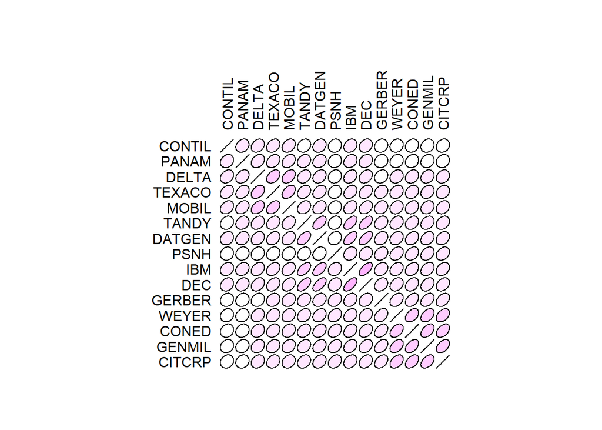

```r
rownames(cor.ind) = colnames(cor.ind)
ord <- order(cor.ind[1,])
ordered.cor.ind <- cor.ind[ord, ord]
plotcorr(ordered.cor.ind, col=cm.colors(11)[5*ordered.cor.ind + 6])
```

#============================================================================= # compute industry factor model R-square values #=============================================================================

```r
r.square.ind = 1 - diagD.hat/diag(cov.ind)
ind.fm.vals = cbind(B.mat, sqrt(diag(cov.ind)), sqrt(diagD.hat), r.square.ind)
colnames(ind.fm.vals) = c(colnames(B.mat), "fm.sd", "residual.sd", "r.square")
ind.fm.vals
```

```
##        TECH OIL OTHER   fm.sd residual.sd r.square
## CITCRP    0   0     1 0.07291     0.05468   0.4375
## CONED     0   0     1 0.07092     0.05200   0.4624
## CONTIL    0   1     0 0.13258     0.11807   0.2069
## DATGEN    1   0     0 0.10646     0.07189   0.5439
## DEC       1   0     0 0.09862     0.05968   0.6338
## DELTA     0   1     0 0.09817     0.07747   0.3773
## GENMIL    0   0     1 0.07013     0.05092   0.4728
## GERBER    0   0     1 0.08376     0.06849   0.3315
## IBM       1   0     0 0.10102     0.06356   0.6041
## MOBIL     0   1     0 0.09118     0.06839   0.4374
## PANAM     0   1     0 0.12222     0.10630   0.2435
## PSNH      0   0     1 0.10601     0.09440   0.2069
## TANDY     1   0     0 0.11159     0.07930   0.4950
## TEXACO    0   1     0 0.09218     0.06972   0.4279
## WEYER     0   0     1 0.07821     0.06157   0.3802
```

# Compute global minimum variance portfolio

```r
w.gmin.ind = solve(cov.ind)%*%rep(1,nrow(cov.ind))
w.gmin.ind = w.gmin.ind/sum(w.gmin.ind)
t(w.gmin.ind)
```

```
##      CITCRP  CONED  CONTIL   DATGEN      DEC  DELTA GENMIL GERBER
## [1,] 0.1401 0.1549 0.02605 0.005638 0.008182 0.0605 0.1615 0.0893
##           IBM   MOBIL   PANAM  PSNH    TANDY  TEXACO  WEYER
## [1,] 0.007214 0.07763 0.03213 0.047 0.004635 0.07469 0.1105
```

# Compare weights with weights from sample covariance matrix

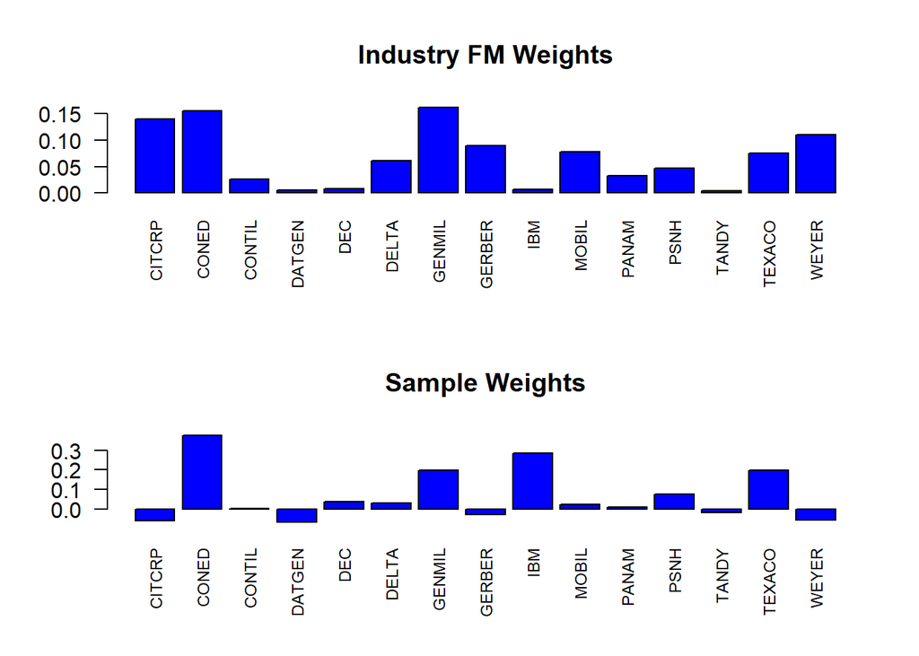

```r
par(mfrow=c(2,1))
barplot(t(w.gmin.ind), horiz=F, main="Industry FM Weights", col="blue", cex.names = 0.75, las=2)
barplot(t(w.gmin.sample), horiz=F, main="Sample Weights", col="blue", cex.names = 0.75, las=2)
```

```r
par(mfrow=c(1,1))
```